# Muhammad Ahmad Hassan

**Economics & Politics Graduate**  
Economics, Policy & Data Analysis

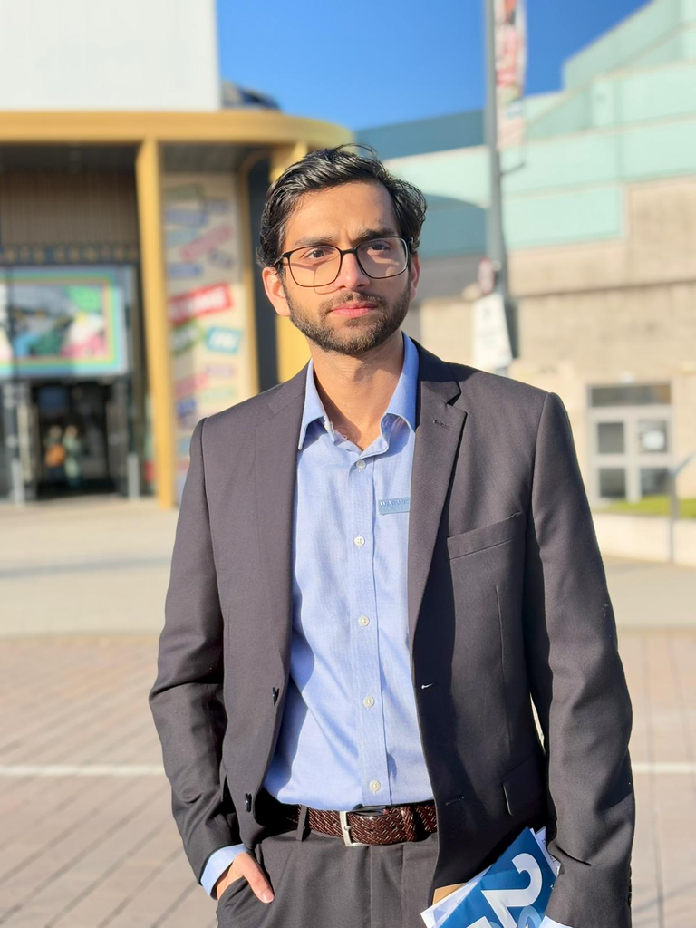

[LinkedIn](https://www.linkedin.com/in/mahmadhassan1/) Email

## Professional Profile

I am an Economics and Politics graduate from the University of Essex with a strong interest in analytical problem-solving, research, strategy, and evidence-based decision-making.

This website presents a selection of my academic work, professional experience, and project-based learning, highlighting my ability to analyse information, communicate clearly, and apply structured thinking across different contexts.

## Areas of Focus

This portfolio is designed for employers, recruiters, and academic/professional contacts who want to understand my background beyond a CV. It highlights my analytical skills, project work, professional experience, and interest in applying structured thinking to real-world problems.

### Analysis & Problem-Solving

Ability to break down complex information, identify patterns, and communicate clear conclusions.

### Research & Evidence

Experience using academic research, data, and structured methods to support evidence-based decision-making.

### Professional Experience

Exposure to banking, operations, customer-facing work, outreach, and stakeholder-focused environments.

## Explore My Work

### Projects

Selected academic and analytical projects showing my research, data, and communication skills.

View projects →

### Experience

A summary of professional, voluntary, and leadership experiences across different settings.

View experience →

### CV

A concise overview of my education, experience, skills, and achievements.

View CV →